# ISCN3 Rebuild

Kathe Todd-Brown, Ursa

3/17/2022

#knitr::opts_chunk$set(eval=TRUE)

Purpose: *This vignette describes the ISCN3 data contributions.*

```r
library(SOCDRaH2)
library(tidyverse)
library(knitr)
library(ggplot2)
library(ggmap)
library(kableExtra)
dataDir <- '~/Desktop/Datasets/ISCN'

knitr::opts_chunk$set(eval=TRUE, echo=FALSE)
```

Site counts for each contributing dataset submision (dataname_sub) in the profile and layer data table.

| dataset_name | dataset_type (dataset_type) | dataset_description | profile_site_count | layer_site_count |
| --- | --- | --- | --- | --- |
| Myers-Smith | new | This data set contains soil data for cores from a transect from the center of the BBC collapse scar (0 m) into the surrounding burn (30 m). Thirty-five cores were collected soil cores along the transe… | NA | 1 |
| Oak Ridge National Lab_Loblolly_DWJ | new | early- and end-rotation soil C and N for ORNL loblolly plantation study | NA | 1 |
| Oak Ridge National Lab_TDE | new | Pre- and posttreatment soil C and N for the Throughfall Displacement Experiment at the Walker Branch Watershed | NA | 1 |
| UMBS_FASET | new | soil C and N and stable isotopes for a subset of plots within the footprints of the reference and treatment eddy-flux towers of the Forest Accelerated Succession Experiment (FASET) at UMBS. | 1 | 1 |
| Schuur | new | Three sites of undisturbed, new karst and old karst; 6 cores per site on the north slope of Alaska Range near Denali | 1 | 3 |
| Heckman lithosequence | new | A lithosequence of forest soils. Ponderosa pine the dominant overstory species. | 4 | 4 |
| USGS Muhs | new | Stratigraphic sequences from 6 sites around Fairbanks, AK where some profiles were sampled 10 meter or more depth. Note that Eva Creek is a broken sequence. | NA | 6 |
| Vogel | new | High elevation-no permafrost, mid elevation-deep permafrost, and low elevation-shallow permafrost black spruce plots | NA | 8 |
| Lu_PIMA | new | 11 of 52 profiles from Ping research on Black Spruce sites; the remaining profiles were excluded because they overlapped with NRCS data | 2 | 11 |
| USGS Harden Yazoo | new | Upland soil C data from sites in the Yazoo basin, MS, collected as a component of the MS Basin Carbon Project | 5 | 11 |
| Kane | new | 12 sites, 12 pits per site, black spruce stands near Fairbanks and Tok | NA | 12 |
| Heckman/Swanston Biscuit Burn | new | Updated soil %C and 14C data for severely burned and unburned soils, sampled after the Biscuit Complex fire. | NA | 14 |
| Lu_LTER | new | 11 profiles from the Bonanza long-term sites and 8 profiles from the Caribou-Poker Creek watershed | 13 | 19 |
| Bonanza LTER | new | Bonanza Creek soils data from long-term plots 1989-1990, 24 sites, 4-5 pits per site | 16 | 24 |
| Lehmann Soil C&BC #1 | new | Soil C & BC survey based on MIR from some LTER and other sites | NA | 31 |
| USGS Harden | new | Bonanza Creek, Erickson Creek, Hess Creek, Tanana Flats and Delta Junction Soils from 2000 to present | 6 | 31 |
| Boby_Mack | new | 92 sites with 4 soil cores each; contains organic and some mineral data of recently burned sites | NA | 38 |
| Jorgensen_YKDE | new | Yukon Delta; no carbon or bulk density | NA | 100 |
| USDA-FS NRS Landscape Carbon Inventory | new | This dataset is the compilation of 7 sites designed to provide “Tier 3”, or landscape scale carbon monitoring of above and belowground carbon pools. Please see reference material. | NA | 165 |
| Lehmann NE US soils | new | Lehmann’s soil chemical characterization, incl. MIR spectra, for the NE region of a cross-US sampling effort. | NA | 172 |
| Permafrost_RCN | analysis | Group data contribution by the Vulnerability of Permafrost RCN. | NA | 211 |
| Bockheim | new | Profiles from drained thaw lake basins near Barrow, AK and along the Dalton Highway on the north slope of the Brooks Range | 26 | 226 |
| Jorgensen_ARCN | new | Northwest Alaska; no carbon or bulk density | NA | 318 |
| Northern Circumpolar Soil Carbon Database (NCSCD) | new | Luke Nave’s adaptation (to ISCN template) of the NCSCD; deep profile SOC data from North America and Eurasia | 510 | 515 |
| Jorgensen_NPS | new | Wrangell and Elias State Parks; no carbon or bulk density; all 1998 (“G00…” names) samples are from B. Lill study | NA | 675 |
| AK DSC Project SOC stock computation | analysis | Gap-filling and SOC computations for layers/horizons comprising the Alaska Deep Soil Carbon Project | 1043 | 1043 |
| USGS_S3C | new | This dataset is derived from the USGS ‘S3C’ (Site-specific soil C) database. The database is a pedon-based, site-specific SOC database for the MS River Basin Carbon Project. The database contains data… | 944 | 1394 |
| Worldwide soil carbon and nitrogen data | new | Global soil carbon and nitrogen data compiled by Paule Zinke et al. from many sources | 4105 | 4473 |
| NRCS Sept/2014 | migration | Pedon-level soils data from the NRCS-Soil Survey Lab, National Cooperative Soil Characterization Database (version date: 11 September 2014). Sites are distributed across all 50 states, with some data … | 14723 | 58233 |

# Data Contributions

## TEMPLATE (`data_name_sub identifier`)

*To use this section remove the code chunk eval arguments and set the current_dataset to the right identifier.*

### Fixed issues

*Copy this from the data report*

### Future issues

*Copy this from the data report*

None we are aware of

## University of Michigan Biological Station Forest Accelerated Succession ExperimenT (`UMBS_FASET`)

The University of Michigan Biological Station Forest Accelerated Succession Experiment (`UMBS_FASET`) data set is uncited and unpublished.

This data set is located in the United States and has 405 layer-level observations and 137 profile-level observations of 1 unique latitude-longitude location.

Citations for the UMBS_FASET data set.

| dataset_name | UMBS_FASET |
| --- | --- |
| dataset_type (dataset_type) | new |
| curator_name | Luke Nave |
| curator_organization | University of Michigan Biological Station |
| curator_email | lukenave@umich.edu |
| acknowledgement | KJ Nadelhoffer and LE Nave. Unpublished soil C and N data from the Forest Accelerated Succession Experiment (FASET). |
| acknowledgement_usage | Data are unpublished. Please use acknowledgement in lieu of citation and consult curators before interpreting these data. |
| modification_date (YYYY-MM-DD) | 2011-09-14 |
| contact_name | Jim Le Moine |
| contact_email | jlemoin@umich.edu |
| dataset_description | soil C and N and stable isotopes for a subset of plots within the footprints of the reference and treatment eddy-flux towers of the Forest Accelerated Succession Experiment (FASET) at UMBS. |

Layer-level catagorical variable counts.

| column_name | value | n |
| --- | --- | --- |
| country (country) | United States | 405 |
| dataset_name_sub | UMBS_FASET | 405 |
| datum (datum) | WGS84 | 383 |
| datum (datum) | NA | 22 |
| hzn_desgn | B | 29 |
| hzn_desgn | NA | 376 |
| soil_series | Cheboygan | 53 |
| soil_series | Rubicon | 255 |
| soil_series | NA | 97 |
| soil_taxon | coarse-loamy, mixed, active, frigid alfic haplorthods | 53 |
| soil_taxon | sandy, mixed, frigid Entic Haplorthods | 255 |
| soil_taxon | NA | 97 |
| state (state_province) | Michigan | 383 |
| state (state_province) | NA | 22 |

Profile-level catagorical variable counts.

| column_name | value | n |
| --- | --- | --- |
| country (country) | United States | 137 |
| dataset_name_sub | UMBS_FASET | 137 |
| datum (datum) | WGS84 | 137 |
| drainagecl (drainage) | excessively | 137 |
| ecoregion | North Central Hardwood Forests | 137 |
| landform (landform) | outwash plain | 137 |
| landscape (landscape) | outwash plain | 137 |
| profile_zero_ref (profile_zero_ref) | topO | 137 |
| runoff (runoff) | negligible | 137 |
| site_perm (site_perm) | very rapid | 137 |
| soil_series | Cheboygan | 24 |
| soil_series | Rubicon | 113 |
| soil_taxon | coarse-loamy, mixed, active, frigid alfic haplorthods | 24 |
| soil_taxon | sandy, mixed, frigid Entic Haplorthods | 113 |
| state (state_province) | Michigan | 137 |
| surface_veg | forest (canopy=Populus,Quercus,Acer), (understory=Acer,Pinus,Amelanchier), ground layer (Pteridium, Vaccinium) | 131 |
| surface_veg | NA | 6 |

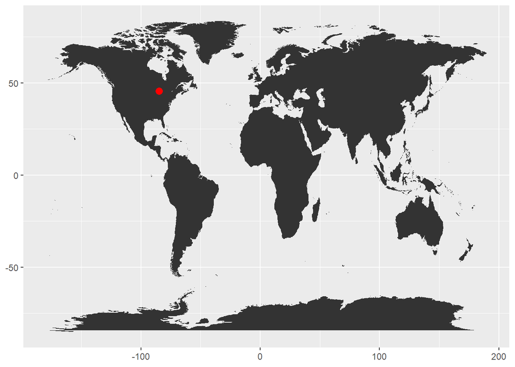

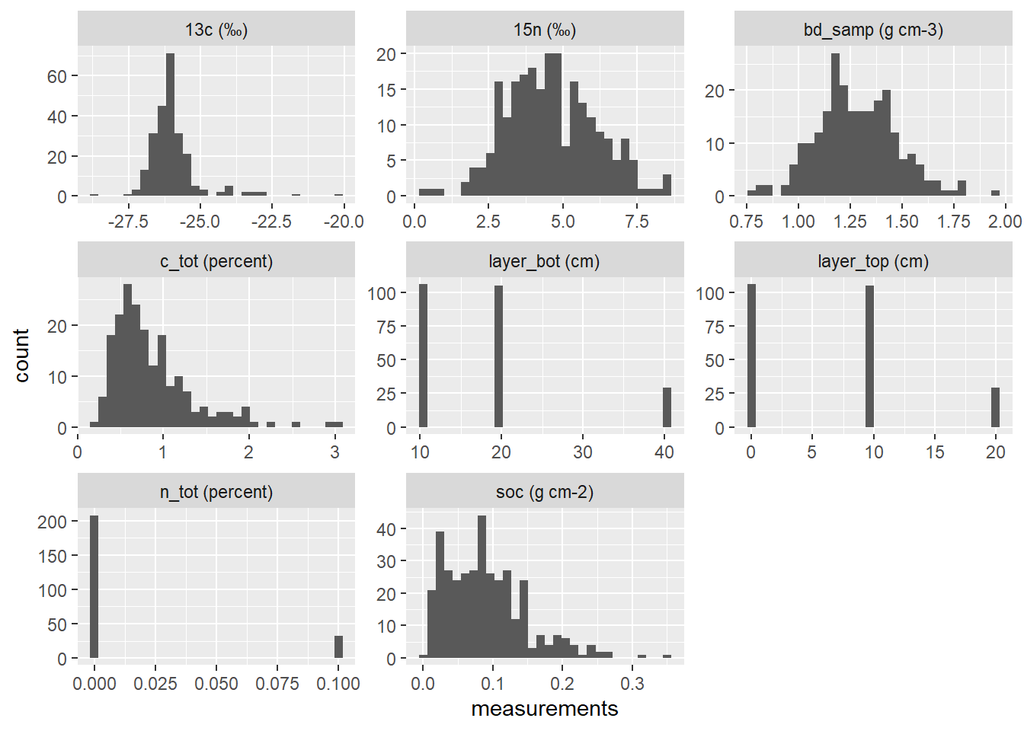

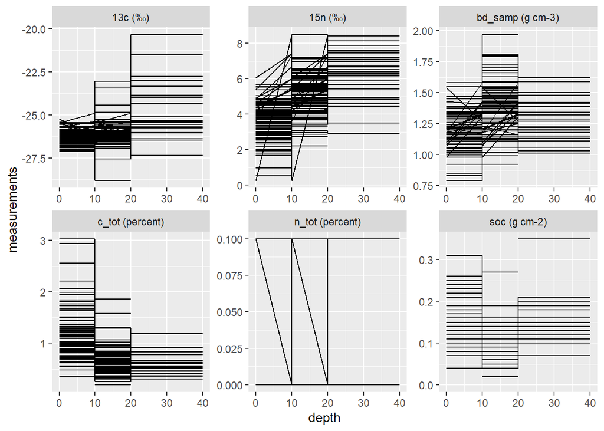

### Fixed issues

Below is a list of known issues that were addressed between ISCN 3 and ISCN 3.3 for the University of Michigan Biological Station Forest Accelerated Succession Experiment (`UMBS_FASET`) data set.

- The UMBS FASET data set is located in the United States and has 405 layer-level observations and 137 profile-level observations of 1 unique latitude-longitude location.
- `ISCN SOC computation` soil organic carbon calculations were removed and duplicate rows deleted.
- Values in the `hzn` column of the `layer` table were reassigned to an NA character from “?”, a nonspecific character.
- Values in `country (country)` column were reassigned to “United States” in the `layer` and `profile` tables because it was the known location of the collection state.

### Future issues

- Citation practices were initially incompatible with CC-BY license for ISCN3; contacting data providers about modifying release for ISCN4
- Data is unpublished, and references “100 yrs of research.” Revisit in ISCN 4. Check and see if data is still being collected at this research site

## Lu_LTER(`Lu_LTER`)

The Lu_LTER data set references @Ping2000, @Ping2002, @Ping2004, @Ping2005, and @Michaelson1996. The `Lu_LTER` data set in ISCN3 contains 103 layer-level observations and 14 profile-level observations after cleaning for ISCN3.5.

Citations for the Lu_LTER data set.

| dataset_name | Lu_LTER | Lu_LTER | Lu_LTER | Lu_LTER | Lu_LTER |
| --- | --- | --- | --- | --- | --- |
| dataset_type (dataset_type) | new | new | new | new | new |
| curator_name | Chien-Lu Ping | Chien-Lu Ping | Chien-Lu Ping | Chien-Lu Ping | Chien-Lu Ping |
| curator_organization | University of Alaska - Fairbanks | University of Alaska - Fairbanks | University of Alaska - Fairbanks | University of Alaska - Fairbanks | University of Alaska - Fairbanks |
| curator_email | pfclp@uaa.alaska.edu | pfclp@uaa.alaska.edu | pfclp@uaa.alaska.edu | pfclp@uaa.alaska.edu | pfclp@uaa.alaska.edu |
| citation | Ping, C.L., Michaelson, G.J., Packee, E.C., Stiles, C.A., Swanson, D.K., Yoshikawa, K., 2005. Soil catena sequences and fire ecology in the boreal forest of Alaska. Soil Science Society of America Jou… | Ping, Chien-Lu. 2000. Soil Horizon Descriptions/Classification and Lab Analysis, Bonanza Creek LTER - University of Alaska Fairbanks. BNZ:149, http://www.lter.uaf.edu/data_detail.cfm?datafile_pkey=149… | Ping, C.L., Michaelson, G.J., Kimble, J.M., Everett, L.R., 2002. Organic carbon stores in Alaska soils. In: R. Lal, J.M. Kimble, R. Follet (Eds.), Agricultural Practices and Policies of Carbon Sequest… | Michaelson, G.J., Ping, C.L., Kimble, J.M., 1996. Carbon storage and distribution in tundra soils of arctic Alaska, U.S.A. Arctic and Alpine Research 28(4), 414-424. | Ping, C.L., Clark, M.H., Swanson, D.K., 2004. Cryosols in Alaska. In: J.M. Kimble (Ed.), Cryosols: Permafrost-affected soils. Springer-Verlag, Berlin, pp. 71–94. |
| modification_date (YYYY-MM-DD) | 2009-12-05 | 2009-12-05 | 2009-12-05 | 2009-12-05 | 2009-12-05 |
| dataset_description | 11 profiles from the Bonanza long-term sites and 8 profiles from the Caribou-Poker Creek watershed | 11 profiles from the Bonanza long-term sites and 8 profiles from the Caribou-Poker Creek watershed | 11 profiles from the Bonanza long-term sites and 8 profiles from the Caribou-Poker Creek watershed | 11 profiles from the Bonanza long-term sites and 8 profiles from the Caribou-Poker Creek watershed | 11 profiles from the Bonanza long-term sites and 8 profiles from the Caribou-Poker Creek watershed |

Layer-level catagorical variable counts.

| column_name | value | n |
| --- | --- | --- |
| country (country) | United States | 103 |
| dataset_name_sub | Lu_LTER | 103 |
| datum (datum) | WGS84 | 103 |
| hzn | A | 12 |
| hzn | B | 40 |
| hzn | C | 22 |
| hzn | E | 1 |
| hzn | O | 28 |
| hzn_desgn | A | 7 |
| hzn_desgn | C | 3 |
| hzn_desgn | 2BC | 1 |
| hzn_desgn | 2Bk1 | 1 |
| hzn_desgn | 2Bk2 | 1 |
| hzn_desgn | 2Bw/Ab | 1 |
| hzn_desgn | 2C | 2 |
| hzn_desgn | 2C2 | 1 |
| hzn_desgn | 2CBk3 | 1 |
| hzn_desgn | 2Cf | 1 |
| hzn_desgn | A1 | 2 |
| hzn_desgn | A2 | 2 |
| hzn_desgn | AC | 1 |
| hzn_desgn | BC | 5 |
| hzn_desgn | BCb | 1 |
| hzn_desgn | Bg | 1 |
| hzn_desgn | Bg’ | 1 |
| hzn_desgn | Bg’‘/Oe’’’ | 1 |
| hzn_desgn | Bg/Oa | 1 |
| hzn_desgn | Bg/Oe | 1 |
| hzn_desgn | Bg1 | 1 |
| hzn_desgn | Bg1/Oa | 1 |

[output cut: 66 more lines]

Profile-level catagorical variable counts.

| column_name | value | n |
| --- | --- | --- |
| 2d_position (2d_position) | backslope | 3 |
| 2d_position (2d_position) | footslope | 1 |
| 2d_position (2d_position) | shoulder | 2 |
| 2d_position (2d_position) | toeslope | 1 |
| 2d_position (2d_position) | NA | 7 |
| country (country) | United States | 14 |
| dataset_name_sub | Lu_LTER | 14 |
| datum (datum) | WGS84 | 14 |
| drainagecl (drainage) | moderately well | 2 |
| drainagecl (drainage) | poorly | 1 |
| drainagecl (drainage) | somewhat poorly | 6 |
| drainagecl (drainage) | well | 5 |
| ecoregion | Interior Highlands | 14 |
| landform (landform) | flood plain | 7 |
| landform (landform) | hill | 7 |
| profile_zero_ref (profile_zero_ref) | topO | 14 |
| soil_series | Coarse-loamy, mixed Aquic Eutrocryepts | 2 |
| soil_series | Coarse-loamy, mixed Lamellic Eutrocryepts | 1 |
| soil_series | Coarse-loamy, mixed Typic Cryaquents | 1 |
| soil_series | Coarse-loamy, mixed Typic Cryofluvents | 1 |
| soil_series | Coarse-loamy, mixed Typic Dystrocryept | 1 |
| soil_series | Coarse-loamy, mixed Typic Dystrocryepts | 1 |
| soil_series | Coarse-loamy, mixed Typic Historthels | 3 |
| soil_series | Coarse-loamy, mixed, nonacidic Fluvaquentic Cryaquepts | 1 |
| soil_series | Coarse-silty, mixed Ruptic Histoturbels | 1 |
| soil_series | Loamy-skeletal, mixed Humic Dystrocryepts | 1 |
| soil_series | Loamy-skeletal, mixed Lithic Aquorthels | 1 |
| state (state_province) | Alaska | 14 |
| vegclass_local | I.A.1.j | 2 |
| vegclass_local | I.A.2.f | 2 |
| vegclass_local | I.A.3.e | 1 |
| vegclass_local | I.B.1.c | 1 |
| vegclass_local | I.B.1.e | 1 |
| vegclass_local | I.C.1.a | 2 |
| vegclass_local | I.C.1.d | 2 |
| vegclass_local | II.A.2.a | 1 |
| vegclass_local | II.B.1.d | 1 |
| vegclass_local | II.B.2.a | 1 |

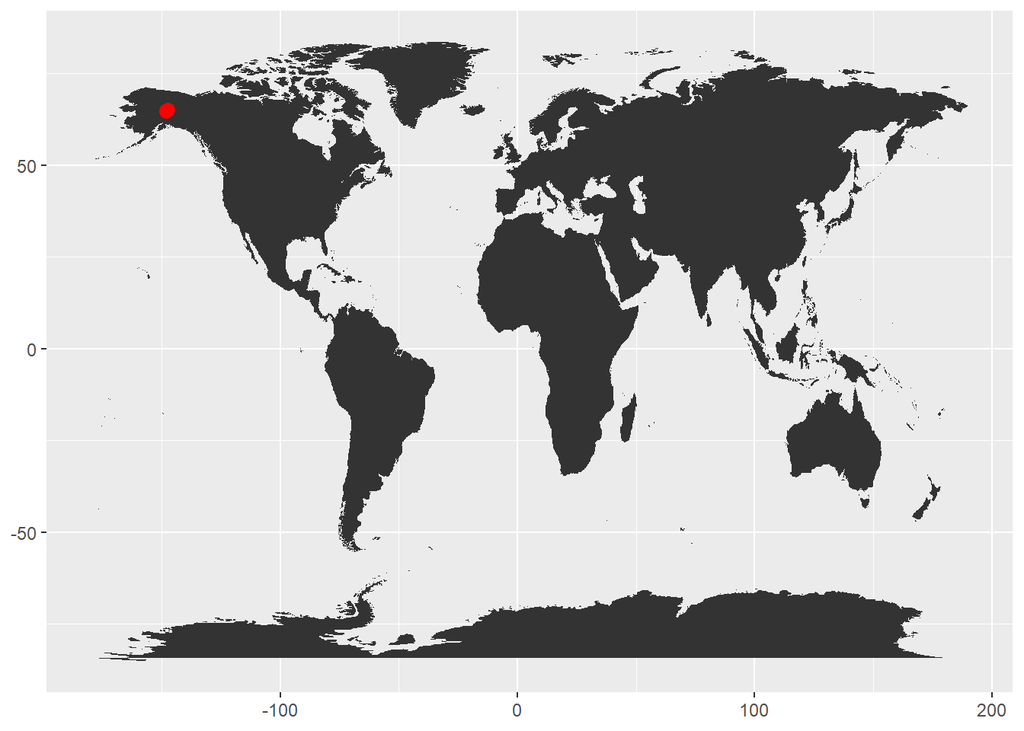

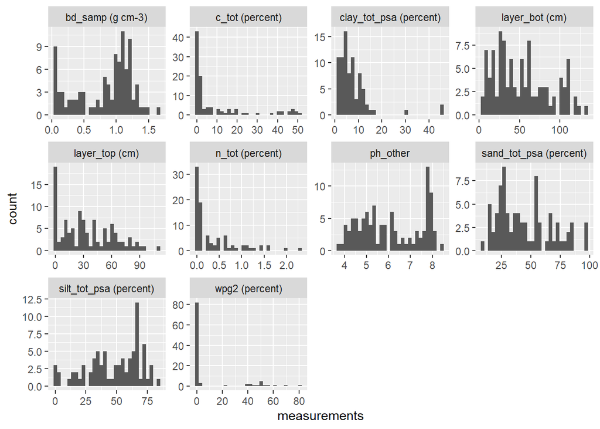

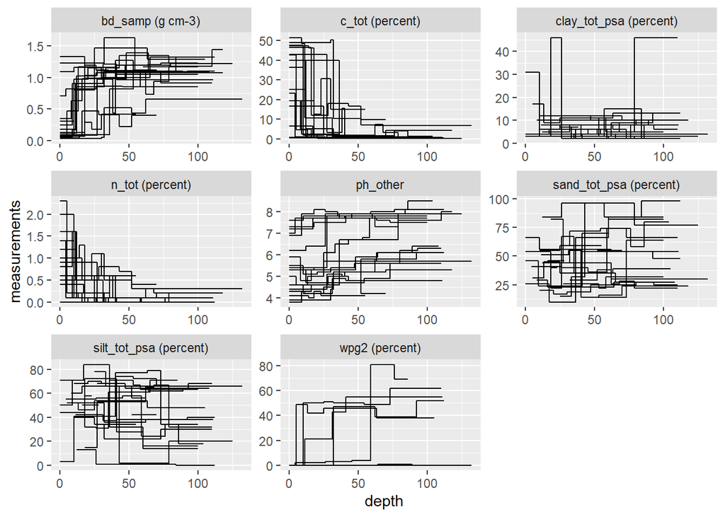

### Fixed issues

Below is a list of know issues that were addressed between ISCN 3 and ISCN 3.3

- In profile, the ISCN SOC to 1m computation rows were removed, as well as any resulting duplicate data.

### Future issues

None we are aware of

## Schuur (`Schuur`)

Citations for the Schuur data set.

| dataset_name | Schuur | Schuur | Schuur |
| --- | --- | --- | --- |
| dataset_type (dataset_type) | new | new | new |
| curator_name | Edward Schuur | Edward Schuur | Edward Schuur |
| curator_organization | University of Florida | University of Florida | University of Florida |
| curator_email | tschuur@ufl.edu | tschuur@ufl.edu | tschuur@ufl.edu |
| citation | Schuur, E.A.G., Crummer, K.G., Vogel, J.G., Mack, M.C., 2007. Plant species composition and productivity following permafrost thaw and thermokarst in Alaskan tundra. Ecosystems 10(2), 280-292. | Schuur, Edward. 2009. The impact of permafrost thaw on ecosystem carbon balance: Eight Mile Lake soil carbon and nitrogen., Bonanza Creek LTER - University of Alaska Fairbanks. BNZ:366, http://www.lte… | Schuur, Edward. 2009. The impact of permafrost thaw on ecosystem carbon balance: Eight Mile Lake soil carbon and nitrogen., Bonanza Creek LTER - University of Alaska Fairbanks. BNZ:366, http://www.lte… |
| modification_date (YYYY-MM-DD) | 2009-12-05 | 2009-12-05 | 2009-12-04 |
| dataset_description | Three sites of undisturbed, new karst and old karst; 6 cores per site on the north slope of Alaska Range near Denali | Three sites of undisturbed, new karst and old karst; 6 cores per site on the north slope of Alaska Range near Denali | Three sites of undisturbed, new karst and old karst; 6 cores per site on the north slope of Alaska Range near Denali |

Layer-level catagorical variable counts.

| column_name | value | n |
| --- | --- | --- |
| country (country) | United States | 153 |
| dataset_name_sub | Schuur | 153 |
| datum (datum) | NAD83 | 153 |
| hzn | ? | 153 |
| hzn_desgn | unknown | 153 |
| state (state_province) | Alaska | 153 |
| vegclass_local | II.C.2.a | 96 |
| vegclass_local | II.D.2.b | 57 |

Profile-level catagorical variable counts.

| column_name | value | n |
| --- | --- | --- |
| country (country) | United States | 4 |
| dataset_name_sub | Schuur | 4 |
| datum (datum) | NAD83 | 4 |
| drainagecl (drainage) | well | 4 |
| ecoregion | Interior Highlands | 4 |
| landform (landform) | alluvial fan | 4 |
| profile_zero_ref (profile_zero_ref) | topO | 4 |
| state (state_province) | Alaska | 4 |
| surface_veg | dominance by shrubs, including blueberry (Vaccinium uliginosum) and cloudberry (Rubus chamaemorus), at the expense of sedges | 4 |
| vegclass_local | II.D.2.b | 4 |

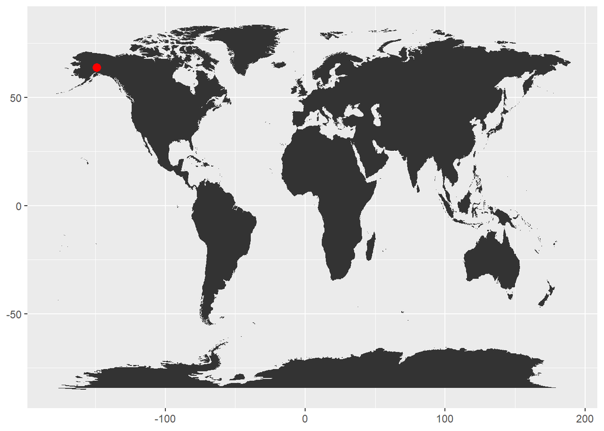

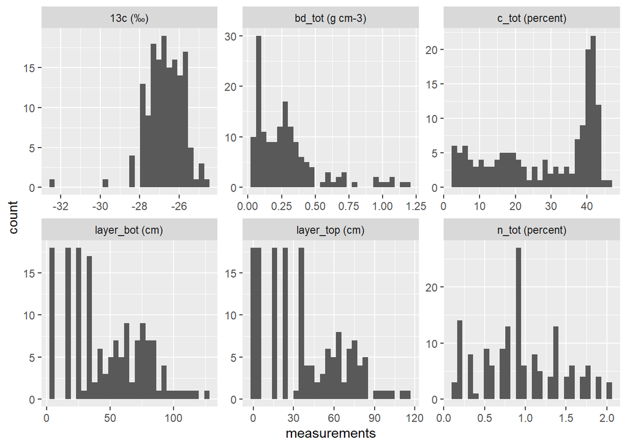

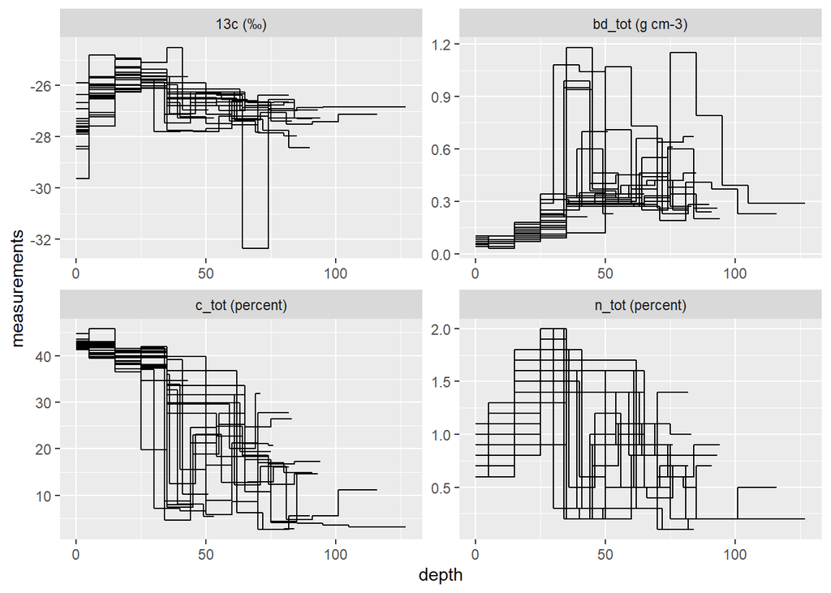

### Fixed issues

In profile, the ISCN SOC to 1m computation rows were removed, getting rid of duplicate data.

### Future issues

None that we are aware of

## Lu_PIMA (`Lu_PIMA`)

Citations for the Lu_PIMA data set.

| dataset_name | Lu_PIMA |
| --- | --- |
| dataset_type (dataset_type) | new |
| curator_name | Chien-Lu Ping |
| curator_organization | University of Alaska - Fairbanks |
| curator_email | pfclp@uaa.alaska.edu |
| citation | Ping, C.L., Michaelson, G.J., Kane, E.S., Packee, E.C., Stiles, C.A., Swanson, D.K., Zaman, N.D., 2010. Carbon stores and biogeochemical properties of soils under black spruce forest, Alaska. Soil Sci… |
| modification_date (YYYY-MM-DD) | 2009-12-05 |
| dataset_description | 11 of 52 profiles from Ping research on Black Spruce sites; the remaining profiles were excluded because they overlapped with NRCS data |

Layer-level catagorical variable counts.

| column_name | value | n |
| --- | --- | --- |
| color | 10YR2/1 | 2 |
| color | 10YR2/1;2/2;5/1 | 1 |
| color | 10YR2/2 | 3 |
| color | 10YR3/3 | 2 |
| color | 10YR4/1;3/1 10YR5/8;2/1CP | 1 |
| color | 10YR4/1;4/6 | 2 |
| color | 10YR4/2 | 1 |
| color | 10YR4/2,7.5YR3/1 | 1 |
| color | 10YR4/2;4/6 | 1 |
| color | 10YR4/2;4/6; 4/N | 1 |
| color | 10YR4/3 | 3 |
| color | 10YR4/3, 2.5Y 4/3, 7.5YR3/2 | 1 |
| color | 10YR4/3, aa+ | 1 |
| color | 10YR4/3;4/2 | 1 |
| color | 10YR4/3;5/2 | 1 |
| color | 10YR4/4 | 3 |
| color | 10YR4/4; 2.5YR3/4; Gley1 3/5GY | 1 |
| color | 10YR4/6,4/4 | 1 |
| color | 10YR4/6;5/6 | 1 |
| color | 10YR5/6; 55%; 2.5Y4/2;5/2 | 1 |
| color | 2.5Y4/1;10YR5/6 | 1 |
| color | 2.5Y4/3 | 3 |
| color | 2.5Y5/2 | 2 |
| color | 2.5YR2.5/1 | 6 |
| color | 2.5YR3/1 | 1 |
| color | 2.5YR3/2 | 1 |
| color | 5Y3/2 | 1 |
| color | 5Y3/3,4/2; 10YR3/3 | 1 |
| color | 5Y4/1 | 1 |
| color | 5YR2.5/1, 5YR4/4 | 1 |

[output cut: 92 more lines]

Profile-level catagorical variable counts.

| column_name | value | n |
| --- | --- | --- |
| 2d_position (2d_position) | shoulder | 1 |
| 2d_position (2d_position) | NA | 1 |
| country (country) | United States | 2 |
| dataset_name_sub | Lu_PIMA | 2 |
| datum (datum) | WGS84 | 2 |
| drainagecl (drainage) | poorly | 1 |
| drainagecl (drainage) | well | 1 |
| ecoregion | Copper Plateau | 1 |
| ecoregion | Interior Bottomlands | 1 |
| landform (landform) | hill | 1 |
| landform (landform) | plain | 1 |
| profile_zero_ref (profile_zero_ref) | topO | 2 |
| state (state_province) | Alaska | 2 |
| vegclass_local | I.A.1.f | 1 |
| vegclass_local | I.A.1.l | 1 |

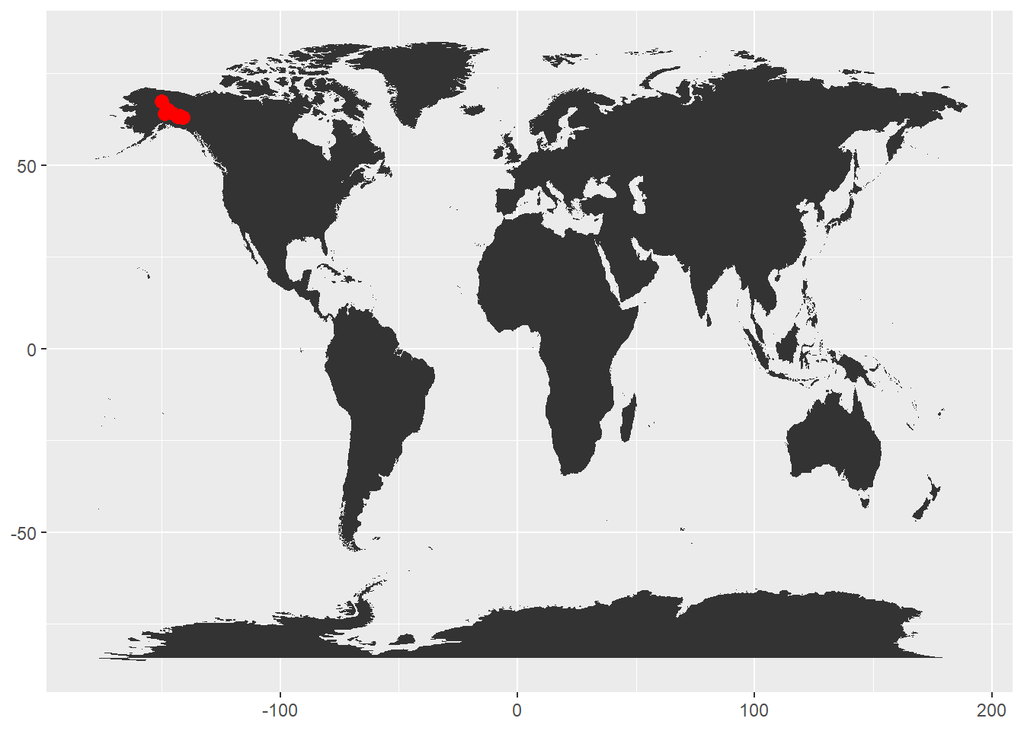

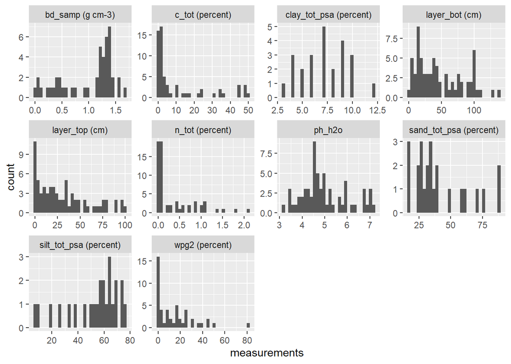

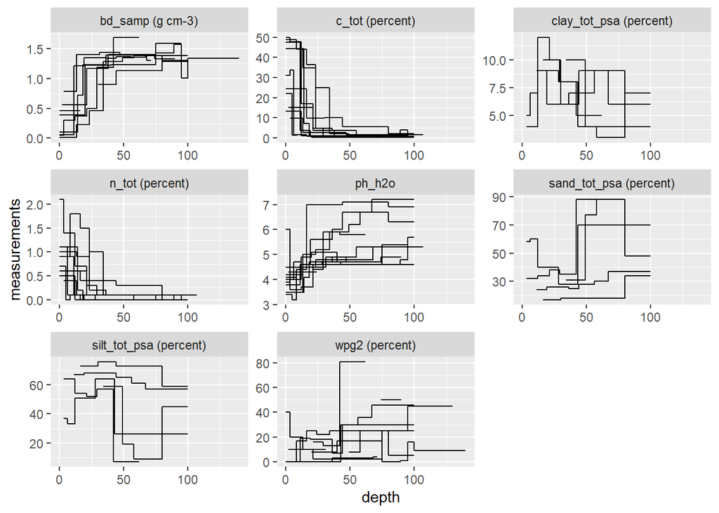

### Fixed issues

- In profile, the ISCN SOC to 1m computation rows were removed, getting rid of duplicate data.
- The layer tables were adjusted to reassign the value “NA” to a column with “?”.
- The clean layer and clean profile table were checked for accuracy of information.
- A citation was added to the bibliography file.
- Four columns were removed from the original dataset that remove the soc columns from both the dataset_layer table and dataset_profile table.

### Future issues

- Cite a database referenced in the dataset_study table
- The url links provided lead to a 404 error page. The correct url for dataone: https://search.dataone.org/view/knb-lter-bnz.366.16
- The datasite download link provided: http://www.lter.uaf.edu/404.php
- This link leads to a 404 error, contacting the researchers is necessary.

## USGS Muhs (`USGS Muhs`)

Citations for the USGS Muhs data set.

| dataset_name | USGS Muhs | USGS Muhs |
| --- | --- | --- |
| dataset_type (dataset_type) | new | new |
| curator_name | Daniel R. Muhs | Daniel R. Muhs |
| curator_organization | USGS | USGS |
| curator_email | dmuhs@usgs.gov | dmuhs@usgs.gov |
| modification_date (YYYY-MM-DD) | 2012-09-26 | 2012-09-25 |
| dataset_description | Stratigraphic sequences from 6 sites around Fairbanks, AK where some profiles were sampled 10 meter or more depth. Note that Eva Creek is a broken sequence. | Stratigraphic sequences from 6 sites around Fairbanks, AK where some profiles were sampled 10 meter or more depth. Note that Eva Creek is a broken sequence. |

Layer-level catagorical variable counts.

| column_name | value | n |
| --- | --- | --- |
| country (country) | United States | 395 |
| dataset_name_sub | USGS Muhs | 395 |
| datum (datum) | NAD83 | 395 |
| hzn | ? | 34 |
| hzn | A | 48 |
| hzn | B | 40 |
| hzn | c | 1 |
| hzn | C | 249 |
| hzn | e | 8 |
| hzn | E | 7 |
| hzn | O | 8 |
| hzn_desgn | A | 1 |
| hzn_desgn | C | 28 |
| hzn_desgn | E | 5 |
| hzn_desgn | O | 3 |
| hzn_desgn | 10Ab | 3 |
| hzn_desgn | 10Bw | 1 |
| hzn_desgn | 10Bwb | 1 |
| hzn_desgn | 10C | 2 |
| hzn_desgn | 11Ab | 3 |
| hzn_desgn | 11Bw | 1 |
| hzn_desgn | 11Bwb | 1 |
| hzn_desgn | 11Cb | 1 |
| hzn_desgn | 12Ab | 1 |
| hzn_desgn | 12Cb | 9 |
| hzn_desgn | 12Cb/residuum | 1 |
| hzn_desgn | 12Cloess/schist) | 1 |
| hzn_desgn | 12Cloess/schits | 1 |
| hzn_desgn | 2/3Ab | 1 |
| hzn_desgn | 2/3ACb | 2 |

[output cut: 130 more lines]

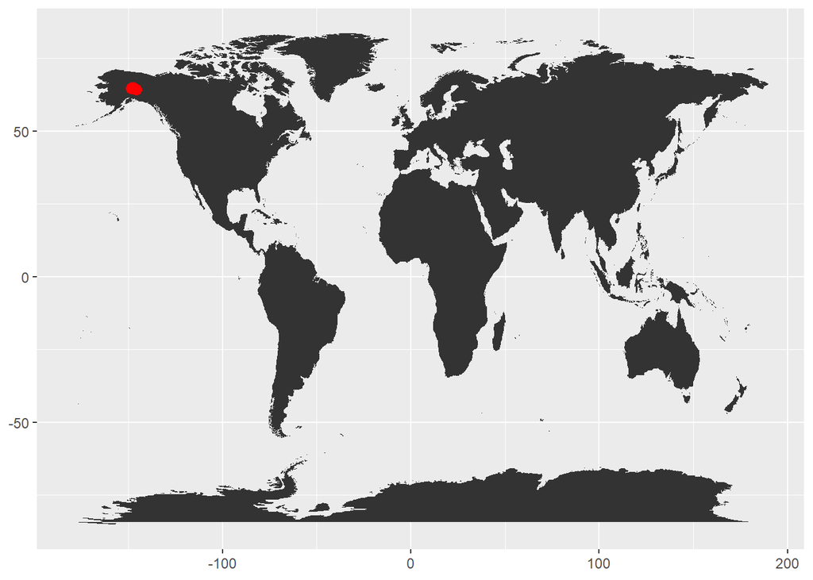

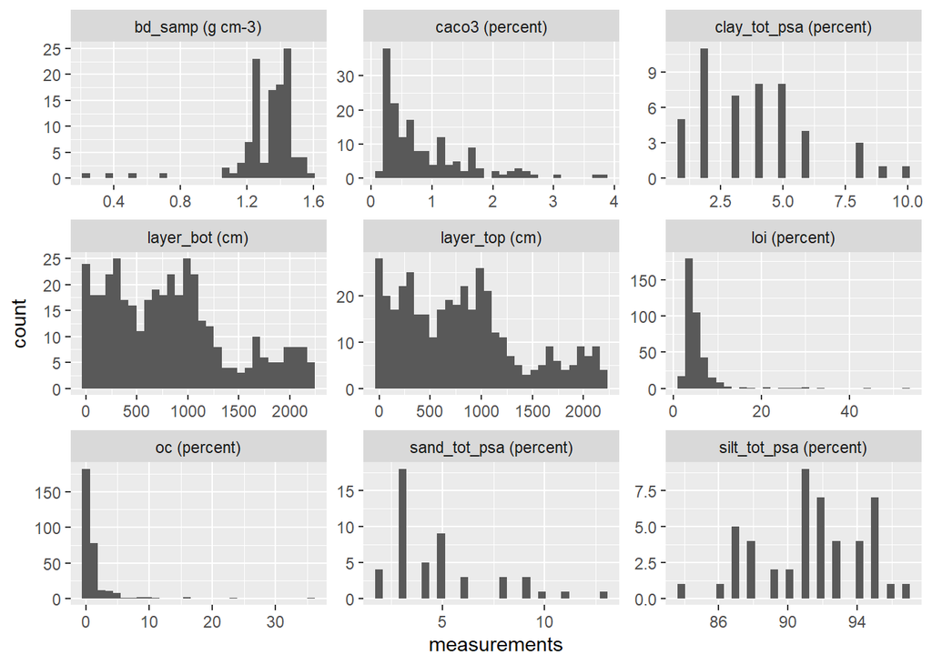

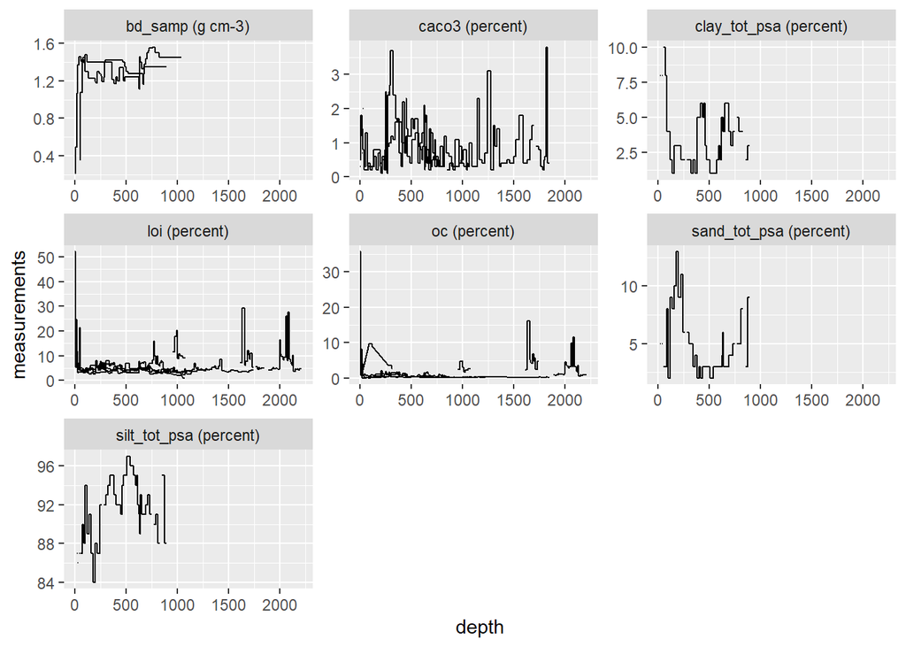

### Fixed issues

- Repeated information on soil carbon stocks was removed from the layer and profile information of the data set.
- There are no duplicate rows that needed to be removed, however, the soil carbon stock columns gap filled by ISCN were removed by ISCN3.5 cleaning.
- In addition, the site note in the data set profile was expanded to a formal citation and added to the ISCN bib file.

### Future issues

None we are aware of

## USGS Harden Yazoo (`USGS Harden Yazoo`)

*To use this section remove the code chunk eval arguments and set the current_dataset to the right identifier.*

Citations for the USGS Harden Yazoo data set.

| dataset_name | USGS Harden Yazoo |
| --- | --- |
| dataset_type (dataset_type) | new |
| curator_name | Jennifer Harden |
| curator_organization | USGS |
| curator_email | jharden@usgs.gov |
| reference | Huntington T, Harden J, Dabney S, Marion D, Alonso C, Sharpe J, Fries T. 1998. SOIL, ENVIRONMENTAL, AND WATERSHED MEASUREMENTS IN SUPPORT OF CARBON CYCLING STUDIES IN NORTHWESTERN MISSISSIPPI. USGS Op… |
| citation | Harden J, Fries T, Huntington T. 1999. MS Basin Carbon Project: Upland soil database for sites in Yazoo Basin, northern MS. USGS Open file report 99-319. |
| citation_usage | use Harden as primary citation, consult Huntington for additional info if needed. |
| modification_date (YYYY-MM-DD) | 2011-05-06 |
| contact_name | Luke Nave |
| contact_email | lukenave@umich.edu |
| dataset_description | Upland soil C data from sites in the Yazoo basin, MS, collected as a component of the MS Basin Carbon Project |

Layer-level catagorical variable counts.

| column_name | value | n |
| --- | --- | --- |
| color | 10-7.5YR4.4. 2.5Y4/2 | 2 |
| color | 10-7.5YR5/4 | 1 |
| color | 10-7.5YR5/6 | 5 |
| color | 10-7.5YR5/6 2.5Y7/2 | 1 |
| color | 10 to 7.5YR5/6 | 2 |
| color | 10YR 5/2d | 1 |
| color | 10YR 5/4 | 2 |
| color | 10YR3/2 | 2 |
| color | 10YR3/2D | 2 |
| color | 10YR3/3 | 2 |
| color | 10YR4/3 | 4 |
| color | 10YR4/3D | 1 |
| color | 10YR4/4 | 3 |
| color | 10YR5/2;7.5YR4/6D | 3 |
| color | 10YR5/2D | 1 |
| color | 10YR5/3 | 3 |
| color | 10YR5/3.5 | 3 |
| color | 10YR5/3D | 1 |
| color | 10YR5/3d;3/3m | 1 |
| color | 10YR5/4 | 14 |
| color | 10YR5/4D | 1 |
| color | 10YR5/6 | 5 |
| color | 10YR5/6 7.5YR4/6 | 2 |
| color | 10YR5/8 7.5YR5/8 2.5Y7/2 | 4 |
| color | 10YR6/2d | 2 |
| color | 10YR6/4 | 1 |
| color | 10YR6/4d | 1 |
| color | 10YR6/6d;5/6m | 1 |
| color | 2.5Y6/2 10YR5/4 | 2 |
| color | 7.5YR 4/4 2.5Y7.2 | 2 |

[output cut: 54 more lines]

Profile-level catagorical variable counts.

| column_name | value | n |
| --- | --- | --- |
| country (country) | United States | 17 |
| dataset_name_sub | USGS Harden Yazoo | 17 |
| datum (datum) | NAD27 | 15 |
| datum (datum) | WGS84 | 2 |
| landform (landform) | alluvial flat | 2 |
| landform (landform) | terrace | 3 |
| landform (landform) | NA | 12 |
| landscape (landscape) | hills | 17 |
| profile_zero_ref (profile_zero_ref) | topO | 17 |
| soil_series | Grenada | 5 |
| soil_series | NA | 12 |
| soil_taxon | FINE-SILTY, MIXED, ACTIVE, THERMIC OXYAQUIC FRAGLOSSUDALF | 5 |
| soil_taxon | Fragiudalf | 10 |
| soil_taxon | NA | 2 |
| state (state_province) | Mississippi | 17 |
| surface_veg | lawn with oak and cedar | 1 |
| surface_veg | lawn with oak and cypress | 1 |
| surface_veg | oak forest | 5 |
| surface_veg | soybeans | 10 |

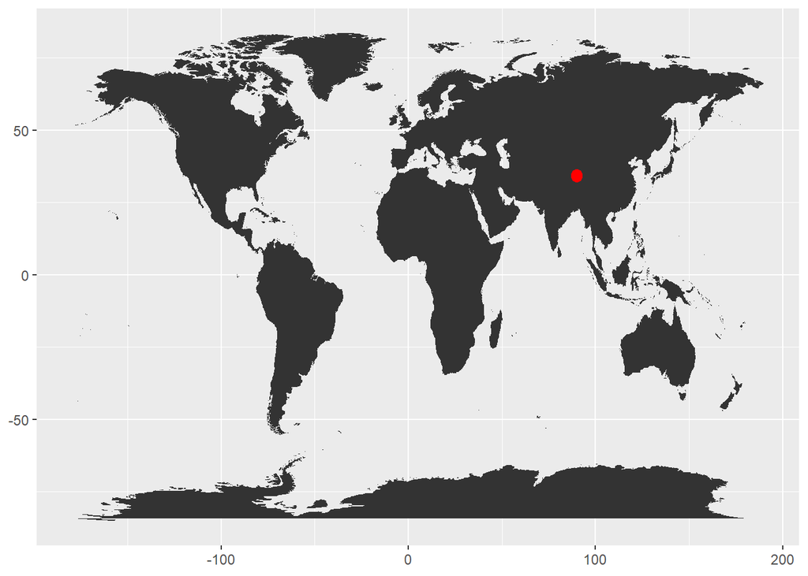

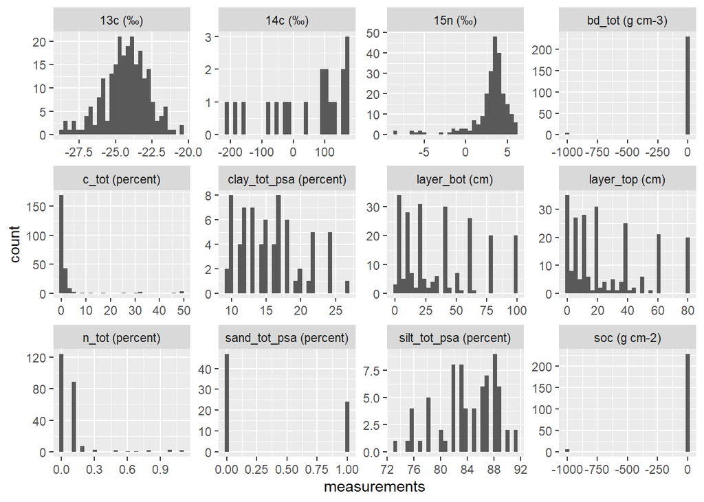

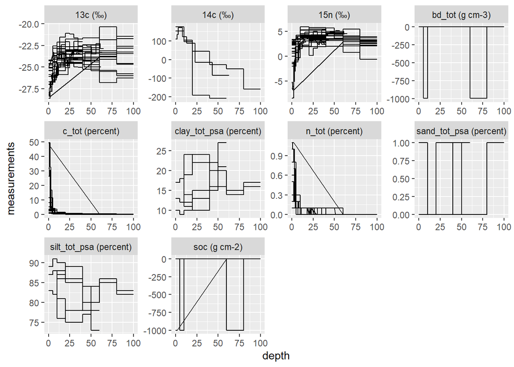

### Future issues

- Fix remaining SOC column in Dataset_layer table?